# HJ

```python
import pandas as pd
import numpy as np
import matplotlib.pyplot as plt
import plotly as py
import seaborn as sns
import plotly.express as px
from plotly.offline import download_plotlyjs, init_notebook_mode, iplot
from scipy import stats
%matplotlib inline
```

```python
df = pd.read_excel('강의자료/data/hj.xlsx')
df
```

|  | cell | Length (㎛) | Length (㎛) - epi | Cingulum (㎛) | Length (㎛)- hypo | Wdith (㎛) - epi | Wdith (㎛) - hypo | 상각하각 와이드 평균 | L:W 비율 |
| --- | --- | --- | --- | --- | --- | --- | --- | --- | --- |
| 0 | #1 | 18.21 | 8.77 | 2.73 | 6.71 | 11.13 | 10.51 | 10.820 | 1.682994 |
| 1 | #2 | 23.60 | 12.11 | 3.67 | 7.82 | 13.65 | 12.84 | 13.245 | 1.781804 |
| 2 | #3 | 24.79 | 13.22 | 3.78 | 7.79 | 13.24 | 12.17 | 12.705 | 1.951200 |
| 3 | #4 | 22.22 | 11.33 | 3.58 | 7.31 | 13.68 | 12.46 | 13.070 | 1.700077 |
| 4 | #5 | 21.17 | 11.45 | 3.50 | 6.22 | 13.41 | 11.49 | 12.450 | 1.700402 |
| 5 | #6 | 21.84 | 10.52 | 3.44 | 7.88 | 12.43 | 11.75 | 12.090 | 1.806452 |
| 6 | #7 | 21.61 | 11.96 | 2.52 | 7.13 | 13.01 | 11.86 | 12.435 | 1.737837 |
| 7 | #8 | 22.74 | 11.65 | 3.34 | 7.75 | 14.49 | 13.61 | 14.050 | 1.618505 |
| 8 | #9 | 19.55 | 9.62 | 3.43 | 6.50 | 11.70 | 9.93 | 10.815 | 1.807675 |
| 9 | #10 | 21.24 | 10.71 | 3.22 | 7.31 | 11.62 | 10.94 | 11.280 | 1.882979 |
| 10 | #11 | 26.98 | 14.26 | 3.85 | 8.87 | 14.15 | 13.43 | 13.790 | 1.956490 |
| 11 | #12 | 20.14 | 10.74 | 2.99 | 6.41 | 11.91 | 10.40 | 11.155 | 1.805468 |
| 12 | #13 | 19.99 | 9.02 | 3.98 | 6.99 | 11.85 | 11.08 | 11.465 | 1.743567 |
| 13 | #14 | 21.42 | 10.43 | 3.30 | 7.69 | 11.81 | 11.39 | 11.600 | 1.846552 |
| 14 | #15 | 20.31 | 10.69 | 3.08 | 6.54 | 11.89 | 10.87 | 11.380 | 1.784710 |
| 15 | #16 | 19.63 | 10.11 | 3.50 | 6.02 | 11.65 | 10.69 | 11.170 | 1.757386 |
| 16 | #17 | 20.57 | 10.04 | 2.29 | 8.24 | 12.25 | 11.82 | 12.035 | 1.709182 |
| 17 | #18 | 16.97 | 7.71 | 2.23 | 7.03 | 10.16 | 10.20 | 10.180 | 1.666994 |
| 18 | #19 | 19.14 | 9.64 | 3.19 | 6.31 | 11.61 | 10.49 | 11.050 | 1.732127 |
| 19 | #20 | 23.35 | 11.51 | 4.12 | 7.72 | 12.70 | 11.14 | 11.920 | 1.958893 |
| 20 | #21 | 23.43 | 11.93 | 3.82 | 7.68 | 13.20 | 12.98 | 13.090 | 1.789916 |
| 21 | #22 | 17.54 | 8.45 | 3.12 | 5.97 | 11.65 | 9.92 | 10.785 | 1.626333 |
| 22 | #23 | 23.65 | 12.58 | 2.98 | 8.09 | 15.45 | 14.25 | 14.850 | 1.592593 |
| 23 | #24 | 21.31 | 11.16 | 3.06 | 7.09 | 14.06 | 12.57 | 13.315 | 1.600451 |
| 24 | #25 | 23.02 | 11.90 | 3.23 | 7.89 | 13.18 | 12.85 | 13.015 | 1.768728 |
| 25 | #26 | 21.26 | 11.75 | 2.96 | 6.55 | 12.21 | 11.25 | 11.730 | 1.812447 |
| 26 | #27 | 25.57 | 13.17 | 3.40 | 9.00 | 12.63 | 11.78 | 12.205 | 2.095043 |
| 27 | #28 | 21.31 | 10.94 | 3.15 | 7.22 | 11.80 | 11.47 | 11.635 | 1.831543 |
| 28 | #29 | 22.24 | 11.14 | 3.43 | 7.67 | 14.24 | 12.89 | 13.565 | 1.639513 |
| 29 | #30 | 19.92 | 9.50 | 2.77 | 7.65 | 13.29 | 12.59 | 12.940 | 1.539413 |
| 30 | #31 | 20.59 | 10.76 | 3.16 | 6.67 | 12.51 | 11.72 | 12.115 | 1.699546 |
| 31 | #32 | 25.08 | 13.23 | 3.28 | 8.57 | 13.51 | 13.15 | 13.330 | 1.881470 |
| 32 | #33 | 17.31 | 7.88 | 4.01 | 5.42 | 10.27 | 9.77 | 10.020 | 1.727545 |
| 33 | #34 | 18.45 | 8.74 | 3.34 | 6.37 | 10.58 | 10.42 | 10.500 | 1.757143 |
| 34 | #35 | 22.02 | 10.99 | 3.34 | 7.69 | 12.52 | 12.09 | 12.305 | 1.789516 |
| 35 | #36 | 18.00 | 8.91 | 2.74 | 6.35 | 11.46 | 9.43 | 10.445 | 1.723313 |
| 36 | #37 | 20.82 | 10.36 | 3.02 | 7.44 | 12.46 | 11.46 | 11.960 | 1.740803 |
| 37 | #38 | 21.16 | 10.69 | 3.52 | 6.95 | 13.49 | 12.20 | 12.845 | 1.647334 |
| 38 | #39 | 22.37 | 11.72 | 3.09 | 7.56 | 13.18 | 11.87 | 12.525 | 1.786028 |
| 39 | #40 | 21.32 | 10.55 | 3.74 | 7.03 | 13.06 | 12.47 | 12.765 | 1.670192 |
| 40 | #41 | 20.91 | 9.48 | 3.34 | 8.09 | 10.97 | 10.43 | 10.700 | 1.954206 |
| 41 | #42 | 20.22 | 10.19 | 3.36 | 6.67 | 10.83 | 10.47 | 10.650 | 1.898592 |
| 42 | #43 | 22.64 | 10.81 | 3.33 | 8.50 | 14.07 | 13.05 | 13.560 | 1.669617 |
| 43 | #44 | 21.55 | 10.57 | 3.53 | 7.45 | 12.94 | 11.59 | 12.265 | 1.757032 |
| 44 | #45 | 20.60 | 9.76 | 4.37 | 6.47 | 12.80 | 12.25 | 12.525 | 1.644711 |
| 45 | #46 | 18.05 | 8.97 | 3.40 | 5.68 | 11.19 | 9.50 | 10.345 | 1.744804 |
| 46 | #47 | 18.68 | 9.18 | 2.58 | 6.92 | 10.15 | 8.70 | 9.425 | 1.981963 |
| 47 | #48 | 24.47 | 13.63 | 3.26 | 7.58 | 14.67 | 14.38 | 14.525 | 1.684682 |
| 48 | #49 | 18.56 | 9.59 | 2.65 | 6.32 | 11.46 | 10.30 | 10.880 | 1.705882 |
| 49 | #50 | 21.49 | 10.66 | 3.90 | 6.93 | 13.50 | 12.75 | 13.125 | 1.637333 |

```python
# 개수, 평균, 표준편차, 최소값, 4분위수, 최대값
df.describe()
```

|  | Length (㎛) | Length (㎛) - epi | Cingulum (㎛) | Length (㎛)- hypo | Wdith (㎛) - epi | Wdith (㎛) - hypo | 상각하각 와이드 평균 | L:W 비율 |
| --- | --- | --- | --- | --- | --- | --- | --- | --- |
| count | 50.000000 | 50.00000 | 50.000000 | 50.000000 | 50.00000 | 50.000000 | 50.00000 | 50.000000 |
| mean | 21.180200 | 10.69360 | 3.292400 | 7.194200 | 12.51340 | 11.592400 | 12.05290 | 1.760580 |
| std | 2.205983 | 1.46307 | 0.449374 | 0.808357 | 1.23315 | 1.279251 | 1.23184 | 0.114413 |
| min | 16.970000 | 7.71000 | 2.230000 | 5.420000 | 10.15000 | 8.700000 | 9.42500 | 1.539413 |
| 25% | 19.937500 | 9.62500 | 3.065000 | 6.542500 | 11.65000 | 10.495000 | 11.07625 | 1.683416 |
| 50% | 21.250000 | 10.69000 | 3.335000 | 7.175000 | 12.51500 | 11.655000 | 12.10250 | 1.744186 |
| 75% | 22.337500 | 11.61500 | 3.515000 | 7.712500 | 13.38000 | 12.545000 | 12.99625 | 1.807369 |
| max | 26.980000 | 14.26000 | 4.370000 | 9.000000 | 15.45000 | 14.380000 | 14.85000 | 2.095043 |

```python
# 분산
np.var(df)
```

```
Length (㎛)          4.769034
Length (㎛) - epi    2.097763
Cingulum (㎛)        0.197898
Length (㎛)- hypo    0.640372
Wdith (㎛) - epi     1.490246
Wdith (㎛) - hypo    1.603754
상각하각 와이드 평균         1.487082
L:W 비율              0.012829
dtype: float64
```

```python
# 표준편차
np.std(df)
```

```
Length (㎛)          2.183812
Length (㎛) - epi    1.448366
Cingulum (㎛)        0.444858
Length (㎛)- hypo    0.800233
Wdith (㎛) - epi     1.220757
Wdith (㎛) - hypo    1.266394
상각하각 와이드 평균         1.219460
L:W 비율              0.113263
dtype: float64
```

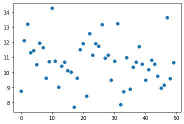

```python
plt.plot(df['Length (㎛) - epi'], 'o')
plt.show()
```

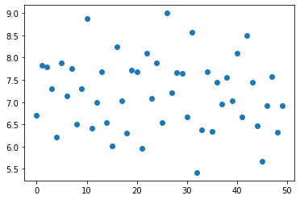

```python
plt.plot(df['Length (㎛)- hypo'], 'o')
plt.show()
```

```python
df1 = df[['Length (㎛) - epi', 'Length (㎛)- hypo']]
df1.head()
```

|  | Length (㎛) - epi | Length (㎛)- hypo |
| --- | --- | --- |
| 0 | 8.77 | 6.71 |
| 1 | 12.11 | 7.82 |
| 2 | 13.22 | 7.79 |
| 3 | 11.33 | 7.31 |
| 4 | 11.45 | 6.22 |

```python
py.offline.iplot([{'x':df['cell'], 'y':df['Length (㎛) - epi'], 'name': 'Length (㎛) - epi'}, {'x':df.index, 'y':df['Length (㎛)- hypo'], 'name': 'Length (㎛)- hypo'}])
```

[interactive chart not shown]

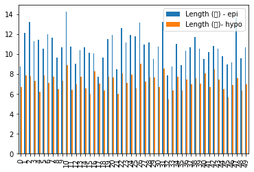

```python
df1.plot.bar()
```

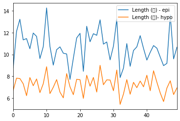

```python
df1.plot.line()
```

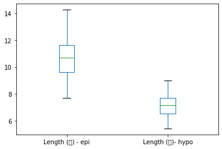

```python
df1.plot.box()
```

```python
df.corr()
```

|  | Length (㎛) | Length (㎛) - epi | Cingulum (㎛) | Length (㎛)- hypo | Wdith (㎛) - epi | Wdith (㎛) - hypo | 상각하각 와이드 평균 | L:W 비율 |
| --- | --- | --- | --- | --- | --- | --- | --- | --- |
| Length (㎛) | 1.000000 | 0.950438 | 0.361292 | 0.807899 | 0.760237 | 0.793468 | 0.792526 | 0.351355 |
| Length (㎛) - epi | 0.950438 | 1.000000 | 0.225081 | 0.658662 | 0.761665 | 0.753696 | 0.772590 | 0.303036 |
| Cingulum (㎛) | 0.361292 | 0.225081 | 1.000000 | 0.022663 | 0.251006 | 0.257063 | 0.259115 | 0.156172 |
| Length (㎛)- hypo | 0.807899 | 0.658662 | 0.022663 | 1.000000 | 0.556566 | 0.658310 | 0.620403 | 0.323545 |
| Wdith (㎛) - epi | 0.760237 | 0.761665 | 0.251006 | 0.556566 | 1.000000 | 0.923158 | 0.979876 | -0.306050 |
| Wdith (㎛) - hypo | 0.793468 | 0.753696 | 0.257063 | 0.658310 | 0.923158 | 1.000000 | 0.981314 | -0.261190 |
| 상각하각 와이드 평균 | 0.792526 | 0.772590 | 0.259115 | 0.620403 | 0.979876 | 0.981314 | 1.000000 | -0.288809 |
| L:W 비율 | 0.351355 | 0.303036 | 0.156172 | 0.323545 | -0.306050 | -0.261190 | -0.288809 | 1.000000 |

## t-test

```python
a = df['Length (㎛) - epi']
b = df['Length (㎛)- hypo']
```

```python
t, p = stats.ttest_ind(a, b)
print("t = " + str(t))
print("p = " + str(p))
```

```
t = 14.803491800143208
p = 9.820033366414268e-27
```

```python
# 표본의 분산(불편추정량) 계산
var_a = a.var(ddof=1)
var_b = b.var(ddof=1)

# [1] 동일한 표본 크기, 동일한 분산
s = np.sqrt((var_a + var_b)/2)

# [2] 동일하거나 동일하지 않은 표본 크기, 동일한 분산
s = np.sqrt(((a.size-1)*var_a+(b.size-1)*var_b) / (a.size+b.size-2))
```

```python
# t-검정 계산
t = (a.mean() - b.mean()) / (s * np.sqrt(1/a.size+1/b.size))
print("t = " + str(t))
```

```
t = 14.803491800143235
```

```python
# 자유도 계산
df = (a.size - 1) + (b.size - 1)

# 유의확률 p값 계산
p = 1 - stats.t.cdf(t,df=df)
print("p = " + str(2*p))
```

```
p = 0.0
```

## Two sampled t-test

Two sampled T-test :-The Independent Samples t Test or 2-sample t-test compares the means of two independent groups in order to determine whether there is statistical evidence that the associated population means are significantly different. The Independent Samples t Test is a parametric test. This test is also known as: Independent t Test.

```python
from scipy.stats import ttest_ind
```

```python
epi = df['Length (㎛) - epi']
hypo = df['Length (㎛)- hypo']
```

```python
epi_mean = np.mean(epi)
hypo_mean = np.mean(hypo)
```

```python
print("epi mean value :", epi_mean)
print("hypo mean value :", hypo_mean)
```

```
epi mean value : 10.693600000000004
hypo mean value : 7.1941999999999995
```

```python
epi_std = np.std(epi)
hypo_std = np.std(hypo)
```

```python
print("epi std value :", epi_std)
print("hypo std value :", hypo_std)
```

```
epi std value : 1.4483656444420379
hypo std value : 0.8002326911592653
```

```python
ttest,pval = ttest_ind(epi,hypo)
print("p-value",pval)
```

```
p-value 9.820033366414268e-27
```

```python
if pval <0.05:
  print("we reject null hypothesis")
else:
  print("we accept null hypothesis")
```

```
we reject null hypothesis
```

## Paired sampled t-test

Paired sampled t-test :- The paired sample t-test is also called dependent sample t-test. It’s an uni variate test that tests for a significant difference between 2 related variables. An example of this is if you where to collect the blood pressure for an individual before and after some treatment, condition, or time point.

H0 :- means difference between two sample is 0

H1:- mean difference between two sample is not 0

```python
ttest,pval = stats.ttest_rel(df['Length (㎛) - epi'], df['Length (㎛)- hypo'])
print(pval)

if pval<0.05:
    print("reject null hypothesis")
else:
    print("accept null hypothesis")
```

```
2.8494884353048398e-27
reject null hypothesis
```

## Z Test

When you can run a Z Test.

Several different types of tests are used in statistics (i.e. f test, chi square test, t test). You would use a Z test if:

Your sample size is greater than 30. Otherwise, use a t test.

Data points should be independent from each other. In other words, one data point isn’t related or doesn’t affect another data point.

Your data should be normally distributed. However, for large sample sizes (over 30) this doesn’t always matter.

Your data should be randomly selected from a population, where each item has an equal chance of being selected.

Sample sizes should be equal if at all possible.

Two-sample Z test- In two sample z-test , similar to t-test here we are checking two independent data groups and deciding whether sample mean of two group is equal or not.

H0 : mean of two group is 0

H1 : mean of two group is not 0

```python
from statsmodels.stats import weightstats as stests
```

```python
ztest ,pval1 = stests.ztest(df['Length (㎛) - epi'], x2=df['Length (㎛)- hypo'], value=0,alternative='two-sided')
print(float(pval1))

if pval<0.05:
    print("reject null hypothesis")
else:
    print("accept null hypothesis")
```

```
1.3907151063291188e-49
reject null hypothesis
```

## Chi-Square Test

Chi-Square Test- The test is applied when you have two categorical variables from a single population. It is used to determine whether there is a significant association between the two variables.

For example, in an election survey, voters might be classified by gender (male or female) and voting preference (Democrat, Republican, or Independent). We could use a chi-square test for independence to determine whether gender is related to voting preference

```python
contingency_table=pd.crosstab(df['Length (㎛) - epi'],df['Length (㎛)- hypo'])
print('contingency_table :-\n',contingency_table)
#Observed Values
Observed_Values = contingency_table.values
print("Observed Values :-\n",Observed_Values)
b=stats.chi2_contingency(contingency_table)
Expected_Values = b[3]
print("Expected Values :-\n",Expected_Values)
no_of_rows=len(contingency_table.iloc[0:2,0])
no_of_columns=len(contingency_table.iloc[0,0:2])
ddof=(no_of_rows-1)*(no_of_columns-1)
print("Degree of Freedom:-",ddof)
alpha = 0.05
from scipy.stats import chi2
chi_square=sum([(o-e)**2./e for o,e in zip(Observed_Values,Expected_Values)])
chi_square_statistic=chi_square[0]+chi_square[1]
print("chi-square statistic:-",chi_square_statistic)
critical_value=chi2.ppf(q=1-alpha,df=ddof)
print('critical_value:',critical_value)
#p-value
p_value=1-chi2.cdf(x=chi_square_statistic,df=ddof)
print('p-value:',p_value)
print('Significance level: ',alpha)
print('Degree of Freedom: ',ddof)
print('chi-square statistic:',chi_square_statistic)
print('critical_value:',critical_value)
print('p-value:',p_value)
if chi_square_statistic>=critical_value:
    print("Reject H0,There is a relationship between 2 categorical variables")
else:
    print("Retain H0,There is no relationship between 2 categorical variables")

if p_value<=alpha:
    print("Reject H0,There is a relationship between 2 categorical variables")
else:
    print("Retain H0,There is no relationship between 2 categorical variables")
```

[output not shown]

[output cut: 130 more lines]

```
 ...
 [0.02 0.02 0.02 ... 0.02 0.02 0.02]
 [0.02 0.02 0.02 ... 0.02 0.02 0.02]
 [0.02 0.02 0.02 ... 0.02 0.02 0.02]]
Degree of Freedom:- 1
chi-square statistic:- 98.00000000000026
critical_value: 3.841458820694124
p-value: 0.0
Significance level:  0.05
Degree of Freedom:  1
chi-square statistic: 98.00000000000026
critical_value: 3.841458820694124
p-value: 0.0
Reject H0,There is a relationship between 2 categorical variables
Reject H0,There is a relationship between 2 categorical variables
```